# CodesRUs-michael

March 9, 2022

Head

| match.id | team1 | team2 | winner | team1.goals | team2.goals | team1.shots | team2.shots | team1.shots.target | team2.shots.target | team1.passes | team2.passes | team1.pass.acc | team2.pass.acc | team1.possession | team2.possession | team1.corners | team2.corners | team1.offsides | team2.offsides | team1.fouls | team2.fouls | team1.yellows | team2.yellows | team1.reds | team2.reds |
| --- | --- | --- | --- | --- | --- | --- | --- | --- | --- | --- | --- | --- | --- | --- | --- | --- | --- | --- | --- | --- | --- | --- | --- | --- | --- |
| 2499719 | Arsenal | Leicester City | team1 | 4 | 3 | 27 | 7 | 10 | 4 | 513 | 166 | 84.7 | 72.2 | 50.3 | 49.7 | 9 | 4 | 6 | 2 | 9 | 12 | 0 | 1 | 0 | 0 |
| 2499720 | Manchester City | Brighton & Hove Albion | team1 | 1 | 0 | 12 | 6 | 3 | 2 | 682 | 124 | 90.5 | 67.4 | 59.7 | 40.3 | 10 | 3 | 1 | 6 | 9 | 6 | 2 | 0 | 0 | 0 |
| 2499721 | Burnley | Chelsea | team1 | 3 | 2 | 9 | 15 | 5 | 5 | 245 | 454 | 82.8 | 88.0 | 50.4 | 49.6 | 5 | 8 | 1 | 2 | 11 | 18 | 3 | 5 | 0 | 1 |
| 2499722 | Crystal Palace | Huddersfield Town | team2 | 0 | 2 | 11 | 8 | 3 | 6 | 291 | 194 | 78.6 | 71.1 | 47.6 | 52.4 | 12 | 9 | 0 | 2 | 7 | 19 | 1 | 3 | 0 | 0 |
| 2499723 | Stoke City | Everton | team2 | 0 | 1 | 10 | 8 | 1 | 3 | 205 | 406 | 76.8 | 84.2 | 47.7 | 52.3 | 7 | 6 | 6 | 2 | 10 | 13 | 1 | 1 | 0 | 0 |

```
## 'data.frame':    1941 obs. of  12 variables:
##  $ team1             : chr  "Arsenal" "Manchester City" "Burnley" "Crystal Palace" ...
##  $ team1.goals       : int  4 1 3 0 0 4 2 0 3 1 ...
##  $ team1.shots       : int  27 12 9 11 10 21 17 4 8 16 ...
##  $ team1.shots.target: int  10 3 5 3 1 5 7 0 4 6 ...
##  $ team1.passes      : int  513 682 245 291 205 404 630 278 290 166 ...
##  $ team1.pass.acc    : num  84.7 90.5 82.8 78.6 76.8 ...
##  $ team1.possession  : num  50.3 59.7 50.4 47.6 47.7 ...
##  $ team1.corners     : int  9 10 5 12 7 11 7 0 3 8 ...
##  $ team1.offsides    : int  6 1 1 0 6 1 2 1 3 2 ...
##  $ team1.fouls       : int  9 9 11 7 10 19 9 13 13 15 ...
##  $ team1.yellows     : int  0 2 3 1 1 2 2 1 0 3 ...
##  $ team1.reds        : int  0 0 0 0 0 0 0 0 0 0 ...
```

```
## 'data.frame':    1941 obs. of  12 variables:
##  $ team2             : chr  "Leicester City" "Brighton & Hove Albion" "Chelsea" "Huddersfield Town" ...
##  $ team2.goals       : int  3 0 2 2 1 0 0 0 2 0 ...
##  $ team2.shots       : int  7 6 15 8 8 7 5 25 12 8 ...
##  $ team2.shots.target: int  4 2 5 6 3 1 3 2 4 2 ...
##  $ team2.passes      : int  166 124 454 194 406 306 160 427 360 534 ...
##  $ team2.pass.acc    : num  72.2 67.4 88 71.1 84.2 ...
##  $ team2.possession  : num  49.7 40.3 49.6 52.4 52.3 ...
##  $ team2.corners     : int  4 3 8 9 6 1 5 13 3 2 ...
##  $ team2.offsides    : int  2 6 2 2 2 4 2 0 1 0 ...
##  $ team2.fouls       : int  12 6 18 19 13 7 8 11 10 4 ...
##  $ team2.yellows     : int  1 0 5 3 1 2 1 2 3 1 ...
##  $ team2.reds        : int  0 0 1 0 0 0 1 0 0 0 ...
```

The dataset teams now has 3,882 records that can be used to analyze number of goals and the factors that influence it. We will run various linear regression models and evaluate them against one another. For this exercise, we will only use continuous variables and then check adjusted R squared to compare models.

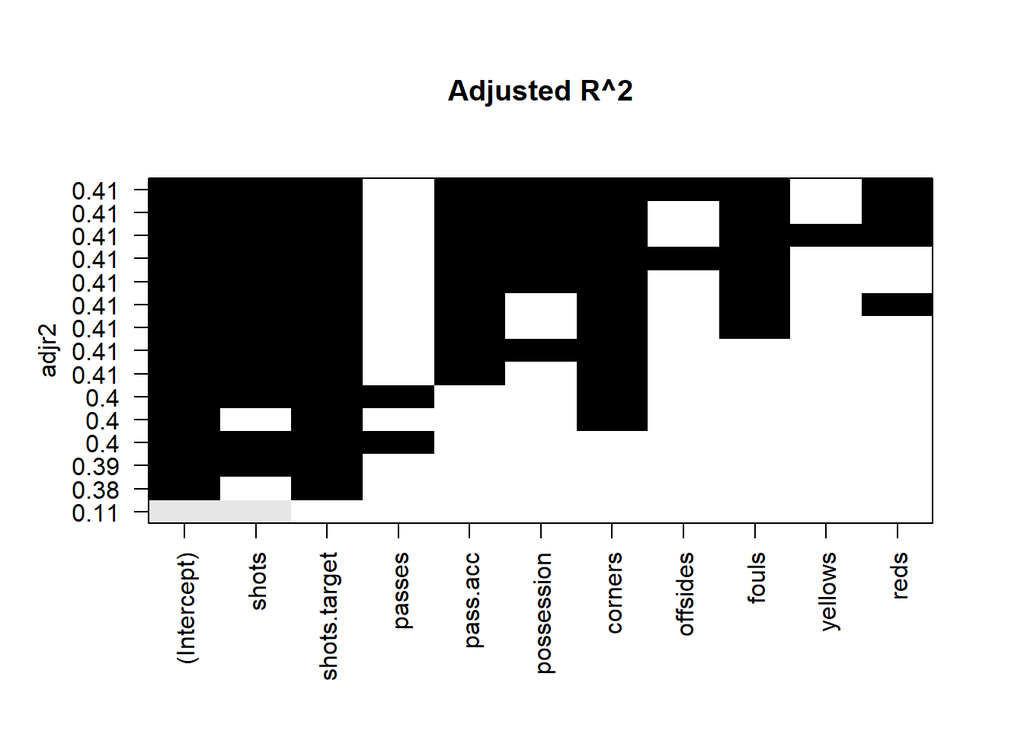

```
##
## Call:
## lm(formula = goals ~ shots + shots.target + pass.acc + possession +
##     corners + offsides + fouls + reds, data = teams_cont)
##
## Residuals:
##    Min     1Q Median     3Q    Max
## -3.162 -0.596 -0.072  0.536  3.520
##
## Coefficients:
##              Estimate Std. Error t value Pr(>|t|)
## (Intercept)  -0.51370    0.25442   -2.02  0.04354 *
## shots        -0.03469    0.00480   -7.23  5.9e-13 ***
## shots.target  0.34868    0.00838   41.60  < 2e-16 ***
## pass.acc      0.01919    0.00315    6.09  1.2e-09 ***
## possession   -0.01075    0.00314   -3.42  0.00063 ***
## corners      -0.04011    0.00623   -6.43  1.4e-10 ***
## offsides      0.00879    0.00841    1.04  0.29613
## fouls        -0.01229    0.00345   -3.57  0.00037 ***
## reds         -0.18556    0.06921   -2.68  0.00736 **
## ---
## Signif. codes:  0 '***' 0.001 '**' 0.01 '*' 0.05 '.' 0.1 ' ' 1
##
## Residual standard error: 0.899 on 3873 degrees of freedom
## Multiple R-squared:  0.411,  Adjusted R-squared:  0.409
## F-statistic:  337 on 8 and 3873 DF,  p-value: <2e-16
```

```
##        shots shots.target     pass.acc   possession      corners     offsides
##         2.54         1.94         1.41         1.32         1.46         1.02
##        fouls         reds
##         1.07         1.01
```

The best model for goals consists of shots, shots.target, pass.acc, possession, corners, offsides, fouls, and reds. This model, however, only has an adjusted R Squared value of 0.409. This indicates that there is some information being left out of the model that could explain variation in number of goals. The only other variables available are passes and yellows. However, those variables appear to be correlated with others already in the model (see below).

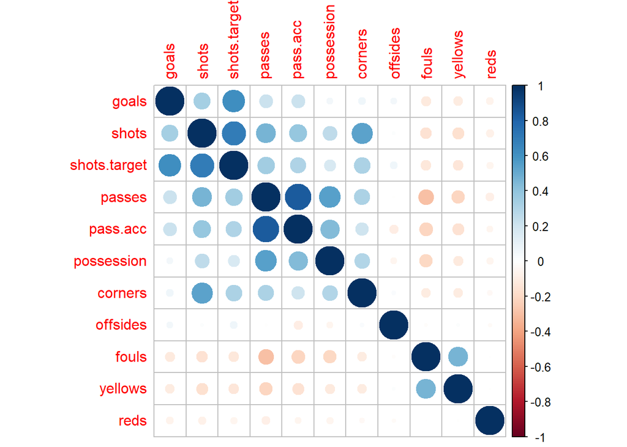

```
##
## Call:
## lm(formula = goals ~ shots + shots.target + pass.acc + possession +
##     corners + offsides + fouls + reds, data = teams_train)
##
## Residuals:
##    Min     1Q Median     3Q    Max
## -3.048 -0.589 -0.076  0.530  3.531
##
## Coefficients:
##              Estimate Std. Error t value Pr(>|t|)
## (Intercept)  -0.48419    0.27870   -1.74   0.0824 .
## shots        -0.03647    0.00528   -6.91  6.0e-12 ***
## shots.target  0.35187    0.00921   38.22  < 2e-16 ***
## pass.acc      0.01853    0.00346    5.35  9.3e-08 ***
## possession   -0.01026    0.00347   -2.96   0.0031 **
## corners      -0.03969    0.00689   -5.76  9.3e-09 ***
## offsides      0.00144    0.00914    0.16   0.8745
## fouls        -0.01069    0.00379   -2.82   0.0048 **
## reds         -0.19270    0.07426   -2.59   0.0095 **
## ---
## Signif. codes:  0 '***' 0.001 '**' 0.01 '*' 0.05 '.' 0.1 ' ' 1
##
## Residual standard error: 0.885 on 3096 degrees of freedom
## Multiple R-squared:  0.418,  Adjusted R-squared:  0.416
## F-statistic:  278 on 8 and 3096 DF,  p-value: <2e-16
```

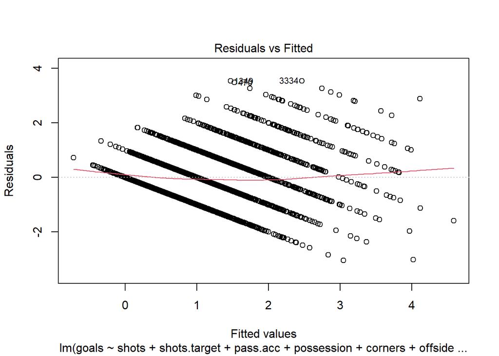

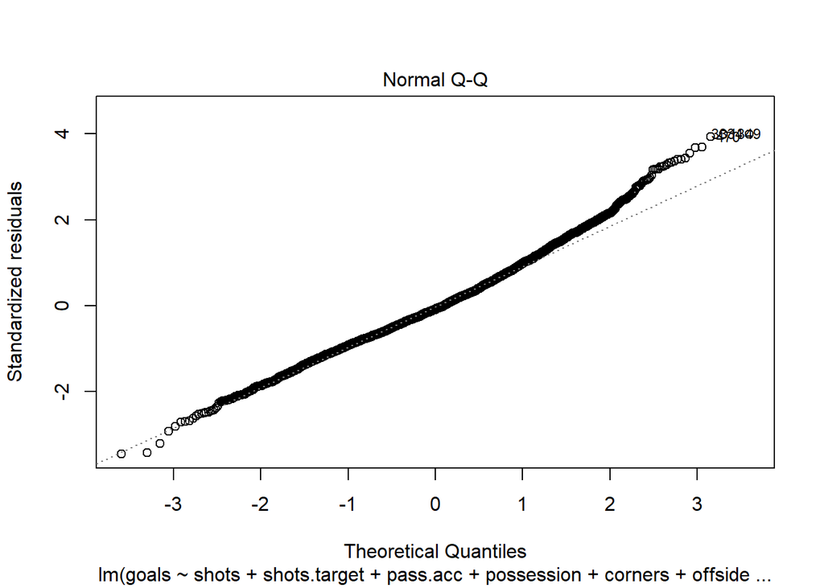

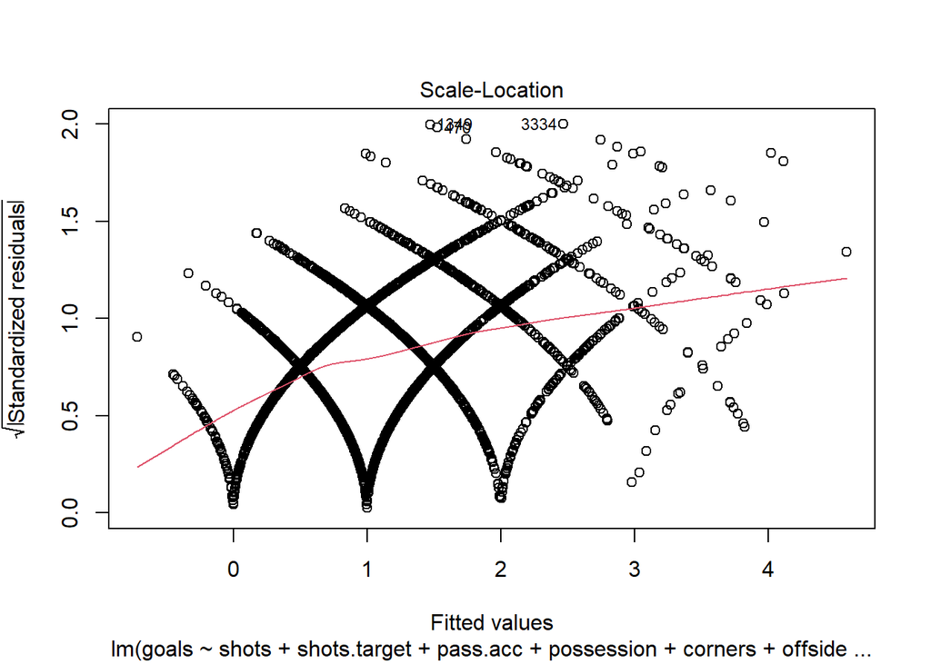

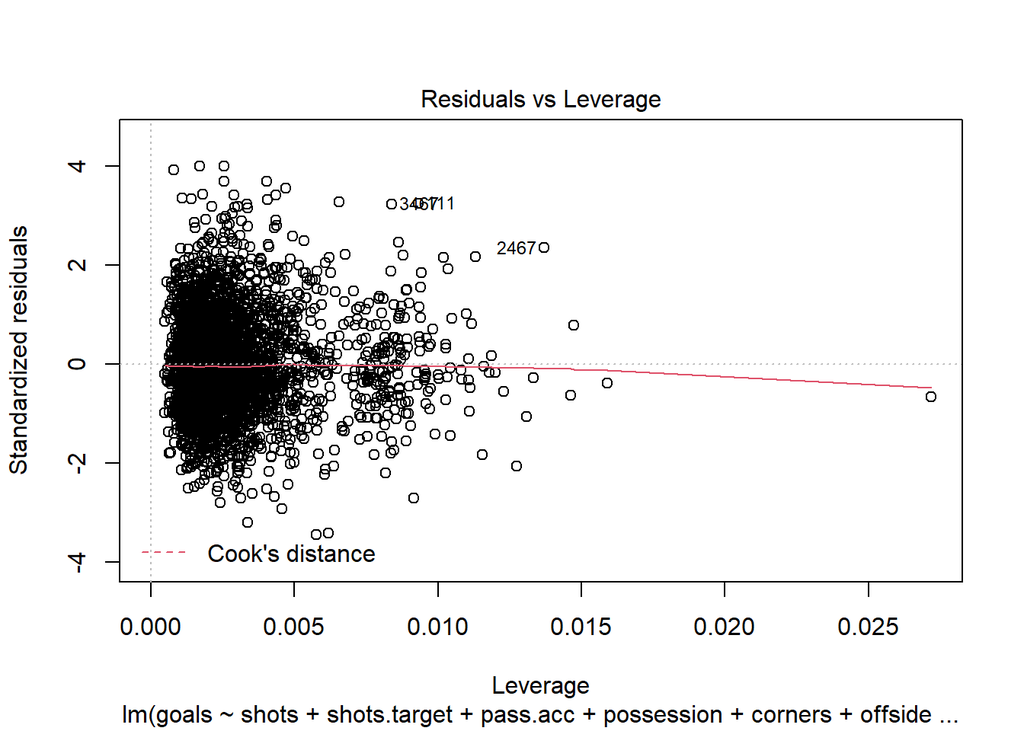

```
##  RMSE    R2
## 5.275 0.418
```

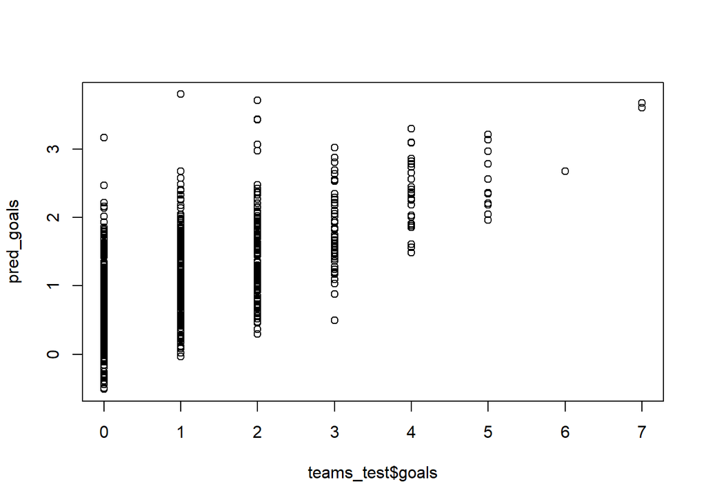

```
##  RMSE    R2
## 5.275 0.418
```

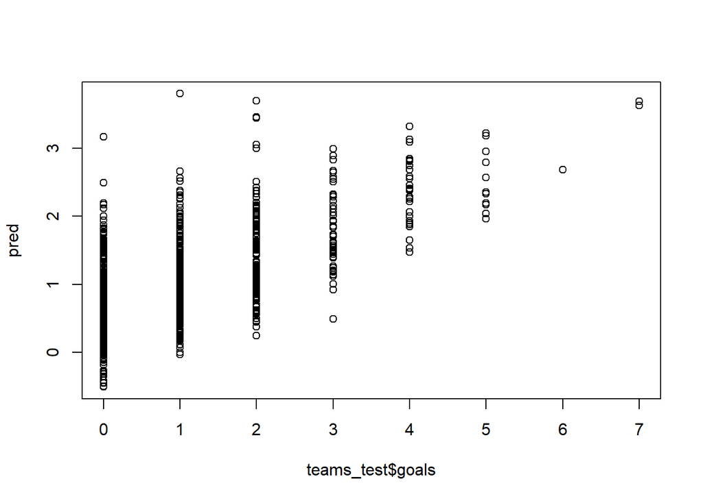

```
##
##       0   1   2   3   4   5   6   7
##   0 255 120  25   0   1   0   0   0
##   1 147 168  65   7   3   3   0   0
##   2  42 107  59  15   6   3   0   0
##   3   2  30  30  12   8   1   0   0
##   4   0   5   7  11   8   3   0   0
##   5   0   0   4   4   3   3   0   1
##   6   0   0   0   1   0   1   0   0
##   7   0   0   0   0   0   0   0   0
```

Head

| match.id | team1 | team2 | winner | team1.goals | team2.goals | team1.shots | team2.shots | team1.shots.target | team2.shots.target | team1.passes | team2.passes | team1.pass.acc | team2.pass.acc | team1.possession | team2.possession | team1.corners | team2.corners | team1.offsides | team2.offsides | team1.fouls | team2.fouls | team1.yellows | team2.yellows | team1.reds | team2.reds |
| --- | --- | --- | --- | --- | --- | --- | --- | --- | --- | --- | --- | --- | --- | --- | --- | --- | --- | --- | --- | --- | --- | --- | --- | --- | --- |
| 2499719 | Arsenal | Leicester City | team1 | 4 | 3 | 27 | 7 | 10 | 4 | 513 | 166 | 84.7 | 72.2 | 50.3 | 49.7 | 9 | 4 | 6 | 2 | 9 | 12 | 0 | 1 | 0 | 0 |
| 2499720 | Manchester City | Brighton & Hove Albion | team1 | 1 | 0 | 12 | 6 | 3 | 2 | 682 | 124 | 90.5 | 67.4 | 59.7 | 40.3 | 10 | 3 | 1 | 6 | 9 | 6 | 2 | 0 | 0 | 0 |
| 2499721 | Burnley | Chelsea | team1 | 3 | 2 | 9 | 15 | 5 | 5 | 245 | 454 | 82.8 | 88.0 | 50.4 | 49.6 | 5 | 8 | 1 | 2 | 11 | 18 | 3 | 5 | 0 | 1 |
| 2499722 | Crystal Palace | Huddersfield Town | team2 | 0 | 2 | 11 | 8 | 3 | 6 | 291 | 194 | 78.6 | 71.1 | 47.6 | 52.4 | 12 | 9 | 0 | 2 | 7 | 19 | 1 | 3 | 0 | 0 |
| 2499723 | Stoke City | Everton | team2 | 0 | 1 | 10 | 8 | 1 | 3 | 205 | 406 | 76.8 | 84.2 | 47.7 | 52.3 | 7 | 6 | 6 | 2 | 10 | 13 | 1 | 1 | 0 | 0 |

Head

| winner | shot.dif | shot.target.dif | pass.dif | pass.acc.dif | possession.dif | corners.dif | offside.dif | foul.dif | yellow.dif | red.dif | shot.ratio | shot.ratio.target | pass.ratio | pass.acc.ratio | possession.ratio | corners.ratio | offside.ratio | foul.ratio | yellow.ratio | red.ratio |
| --- | --- | --- | --- | --- | --- | --- | --- | --- | --- | --- | --- | --- | --- | --- | --- | --- | --- | --- | --- | --- |
| team1 | 20 | 6 | 347 | 12.48 | 0.53 | 5 | 4 | -3 | -1 | 0 | 20 | 6 | 347 | 12.48 | 0.53 | 5 | 4 | -3 | -1 | 0 |
| team1 | 6 | 1 | 558 | 23.06 | 19.31 | 7 | -5 | 3 | 2 | 0 | 6 | 1 | 558 | 23.06 | 19.31 | 7 | -5 | 3 | 2 | 0 |
| team1 | -6 | 0 | -209 | -5.21 | 0.89 | -3 | -1 | -7 | -2 | -1 | -6 | 0 | -209 | -5.21 | 0.89 | -3 | -1 | -7 | -2 | -1 |
| team2 | 3 | -3 | 97 | 7.59 | -4.83 | 3 | -2 | -12 | -2 | 0 | 3 | -3 | 97 | 7.59 | -4.83 | 3 | -2 | -12 | -2 | 0 |
| team2 | 2 | -2 | -201 | -7.45 | -4.61 | 1 | 4 | -3 | 0 | 0 | 2 | -2 | -201 | -7.45 | -4.61 | 1 | 4 | -3 | 0 | 0 |